# Technical Guidelines Series - Part 2

Joy Kumagai

**Prepared by Joy Kumagai - Technical Support Unit of Knowledge and Data**  
**Reviewed by Aidin Niamir - Head of the Technical Support Unit of Knowledge and Data**

17 Nov 2020

## **2. Preparing and mapping data to IPBES Regions and Sub-regions**

The guide will show how to aggregate and map FAO data according to the IPBES Regions and Sub-Regions polygons using R. For this exercise, we chose the FAO population data but any FAOSTAT dataset can be used.

Begin by loading the following packages.

```r
library(sf)
library(tidyverse)
library(FAOSTAT)
library(httr) # to download shapefiles off of Zenodo
```

### I. Downloading Necessary Data

#### a. Downloading FAO data

The first step is to download and unzip the FAO data. The function GET() from the httr package can be used to retrieve the FAO data from a url. The url can be found in FAO STAT’s data description file [here.](http://fenixservices.fao.org/faostat/static/bulkdownloads/datasets_E.xml)

```r
GET("http://fenixservices.fao.org/faostat/static/bulkdownloads/Population_E_All_Data_(Normalized).zip",
    write_disk("FAO_population.zip", overwrite = T)) # Status 200 indicates a successful download
## Response [http://fenixservices.fao.org/faostat/static/bulkdownloads/Population_E_All_Data_(Normalized).zip]
##   Date: 2020-11-17 10:31
##   Status: 200
##   Content-Type: application/x-zip-compressed
##   Size: 1.51 MB
## <ON DISK>  C:\Users\jkumagai\Documents\IPBES\R\Geoinformatics\Technical Guidelines Series\Mapping_Regions\FAO_population.zip

unzip("FAO_population.zip") # unzips the data
```

#### b. Downloading IPBES regions and subregions

Now we will download the shapefile of the IPBES Regions and Sub-regions off of Zenodo. This can be accomplished manually or through a few lines of code.

To download the shapefile manually, please go to the [IPBES Regions and Sub-Regions Zenodo entry](https://doi.org/10.5281/zenodo.3923633).

To do this through a script, first identify the record ID of the Zenodo entry, which is the numbers following “*zenodo.*” at the end of the DOI. We then create a URL with the record ID and query the API for information about the record.

```r
recordID <- "3923633"
url_record <- paste0("https://zenodo.org/api/records/", recordID)
record <- GET(url_record)
record # Status 200 indicates a successful download
## Response [https://zenodo.org/api/records/3928281]
##   Date: 2020-11-17 10:31
##   Status: 200
##   Content-Type: application/json
##   Size: 6.41 kB
```

Now, we can inspect the contents downloaded with the function content()

```r
View(content(record)) # view displays the output in a human readable form within R Studio
```

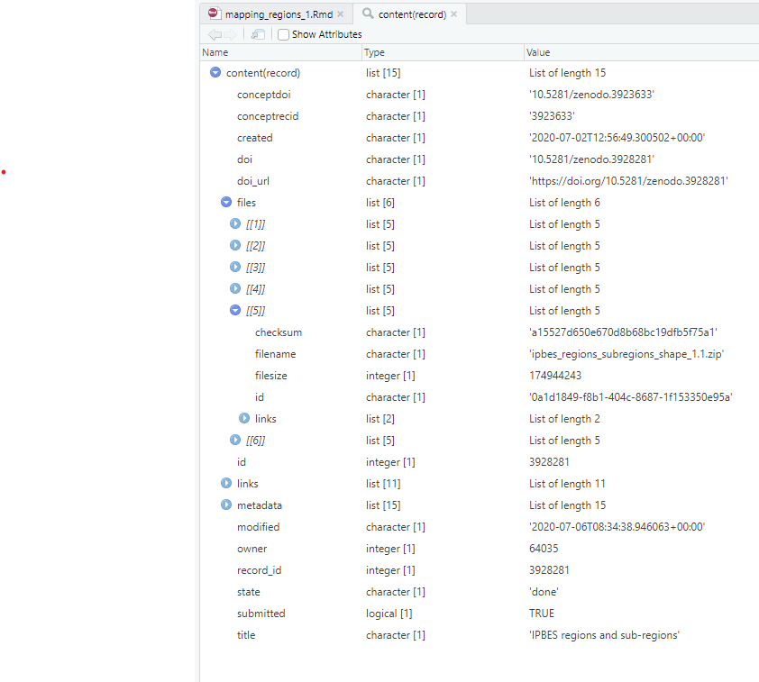

Above shows the resulting R Studio window which displays what was downloaded in a human readable form

This information we received contains metadata for the record, and within this we can find the specific URL to download the Ipbes regions and sub-regions shapefile. We then use this URL and the function GET() to download the shapefile.

```r
# Contains the url to download the shapefile
url_shape <- content(record)$files[[5]]$links$download

GET(url_shape, write_disk("ipbes_regions_subregions.zip", overwrite = T)) # Downloads shapefile
## Response [https://zenodo.org/api/files/581f2706-24e9-43d0-a776-0ce97f377938/ipbes_regions_subregions_shape_1.1.zip]
##   Date: 2020-11-17 10:32
##   Status: 200
##   Content-Type: application/octet-stream
##   Size: 175 MB
## <ON DISK>  C:\Users\jkumagai\Documents\IPBES\R\Geoinformatics\Technical Guidelines Series\Mapping_Regions\ipbes_regions_subregions.zip
unzip("ipbes_regions_subregions.zip") # unzips shapefile
```